# Regression 2: Multiple regression

March 23 2022

```r
library(tidyverse)
library(tidymodels)
library(scatterplot3d)
library(viridis)
```

# Bulletin

- Due today
  - prep quiz 06
- Upcoming
  - Draft report due Monday March 28 to GitHub. Have your .Rmd **and** a PDF in GitHub

# Today

By the end of today, you will…

- understand least squares objective
- explain and compare $R^2$ statistics
- conduct a hypothesis test about a particular $\beta_i$
- model interactions between variables

We’ll continue examining the Palmer penguin dataset.

```r
data(penguins)
```

Use `?penguins` or [click here](https://github.com/allisonhorst/palmerpenguins) for more info about the dataset.

# Last time

## One predictor model

Recall that $y$ is the actual observed outcome (from the data) and $\hat{y}$ is the predicted outcome from the fitted model.

The fitted one predictor linear model:

$$\hat{y} = \hat{\beta_0} + \hat{\beta_1} x_1$$
where $\hat{\beta}$ are the fitted estimates of the true parameters $\beta$ that could be computed if we had the entire population data.

- How did we find $\hat{\beta_0}$ and $\hat{\beta_1}$?

We used the function `linear_reg` with the `lm` engine to fit the model. From the documentation, the ‘lm’ engine “uses **ordinary least squares** to fit models with numeric outcomes.”

# Ordinary Least Squares

The objective of ordinary least squares regression is to find the $\hat{\beta}$ that minimize the sum of square residuals,

$$\sum_{i=1}^n \epsilon_i ^2$$
where $n$ is the number of observations (rows in the data) and

$$\epsilon_i = y_i - \hat{y_i}$$

Side note: one can show that minimizing the sum of square residuals yields the best possible $\hat{\beta}$s when certain assumptions are made, e.g. when $\epsilon_i \sim Normal$

## Exercise 1

[Click here to play with the interactive example](https://seeing-theory.brown.edu/regression-analysis/index.html#section1)

Describe what you see.

# $R^2$

Once we fit a model according to the least squares criteria above, how do we assess how well our predictors explain the outcome? We can use a statistic called $R^2$

## Conceptualize $R^2$

Math definition:

$$R^2 = 1 - \frac{\sum_i^n \epsilon_i^2}{\sum_i^n (y_i - \bar{y})^2}$$

Word definition:

$$R^2 = 1 - \frac{\text{sum of squared error}}{\text{sum of square distance from mean in data}}$$

Let’s focus on the second term to build intuition.

- The numerator “sum of squared error” is a measure of how wrong our model is (the amount of variability *not* explained by the model)
- The denominator is proportional to the variance i.e. the amount of variability in the data.
- Together, the fraction represents the proportion of variability *not* explained by the model.

If the sum of squared error is 0, then the model explains all variability and $R^2 = 1 - 0 = 1$.

If the proportion of error not explained is $1$, i.e. the sum of squared error is the same as all the variability in the data, then model does not explain any variability and $R^2 = 1 - 1 = 0$.

Final take-away: $R^2$ is a measure of the proportion of variability the model explains. An $R^2$ of 0 is a poor fit and $R^2$ of 1 is a perfect fit.

## Example: $R^2$

A single predictor model: flipper length explains body mass.

```r
bm_flipper_fit = linear_reg() %>%
set_engine("lm") %>%
fit(body_mass_g ~ flipper_length_mm, data = penguins)

glance(bm_flipper_fit) %>%
  select(r.squared)
```

| r.squared |
| --- |
| 0.7589925 |

## Exercise 2

Next, build a single predictor model with bill length as the predictor of body mass. Compare the $R^2$ to the model above.

```r
# code here
```

## Exercise 3

Next, build a multiple regression model with two predictors of body mass: bill length and flipper length.

- Before writing any code, do you think $R^2$ will increase, decrease or stay the same? Why?

```r
# code here
```

- Report $R^2$ and discuss

# Hypothesis testing in a regression framework

This is the model from the previous exercise:

$$y = \beta_0 + x_1 \beta_1 + x_2 \beta_2$$

$y$: body mass (g) $x_1$: flipper length (mm) $x_2$: bill length (mm)

We didn’t see a big increase in $R^2$ when adding bill length as a second predictor of body mass.

Let’s conduct a hypothesis test in a regression framework. If bill length does not help us explain body mass, then $\beta_2$ might as well be 0. Within the framework of hypothesis testing:

$H_0$: $\beta_2 = 0$

$H_A:$ $\beta_2 \neq 0$

For OLS regression, our test statistic is

$$T = \frac{\hat{\beta} - 0}{\text{SE}_{\hat{\beta}}} \sim t_{n - 2}$$
We want to see if our observed statistic, $\hat{T}$, falls far in the tail under the null.

`R` takes care of much of this behind the scenes with the tidy output and reports a p-value for each $\beta$ by default.

## Exercise 4

Display your model below in tidy format. Compare the p-value to one you calculate manually using the equation above.

```r
# code here
```

```r
# code here
```

Is $\beta_{\text{bill length}}$ significant at the $\alpha = 0.05$ level? State your conclusion.

# Next time

## Interactions

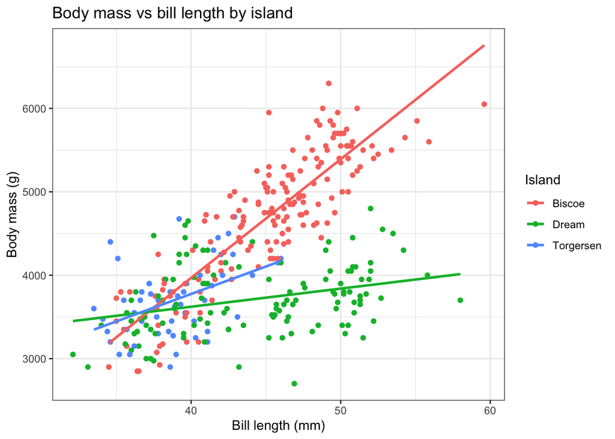

```r
penguins %>%
  ggplot(aes(x = bill_length_mm, y = body_mass_g, color = island)) +
  geom_point() +
  theme_bw() +
  geom_smooth(method = 'lm', se = F) +
  labs(x = "Bill length (mm)", y = "Body mass (g)", title = "Body mass vs bill length by island", color = "Island")
```

- What’s going on in the figure above?